# Tutorial 3: Trajectory inference for individuals

This tutorial demonstrates how to conduct trajectory inference at the individual level using predefined CMs. For a given CM, we analysis the frequencies of corresponding cell states to evaluate inter-sample heterogeneity and construct a potential dynamic trajectory across sample. The trajectory can be linked with phenotypic data and facilitates the exploration of fundamental insights into multicellular biology.

### Loading packages

```r
library(CoVarNet)
```

Implementation of trajectory inference necessitates configuration of a Python environment(v3.12.2) and installation of packages Scanpy(v1.11.0), Palantir(v1.3.3).  
These versions are used for testing the CoVarNet code. Other versions might work too.

```r
use_python("/raid1/cyh/app/miniconda3/envs/tjt/bin/python", required = TRUE)
py_config()

sc <- reticulate::import("scanpy")
pa <- reticulate::import("palantir", convert = FALSE)
```

### Preparing data

```r
mat <- readRDS("./data/example_discovery.rds")
freq <- freq_calculate(mat)
```

```
## `mutate_if()` ignored the following grouping variables:
## • Column `majorCluster`
```

```r
ann=read.csv("./data/BreastCellAtlas_meta.csv",row.names = 1)

network <- readRDS("./data/network.rds")
cm_activity <- t(scoef(network$raw))
```

Here we exclusively include breast data derived from a large-scale cohort(Tapsi Kumar et al., *Nature*) and retain those samples with a known menopausal status for our analysis.

```r
sample <- unique(mat[(mat$cohortName == "BreastCellAtlas"),"sampleID"])
sample=sample[order(sample)]

meta=cbind(t(freq[,sample]),ann[sample,],cm_activity[sample,])
meta <- meta[meta$Menopause != "Unknown", ]
```

### Trajectory inference

The CM12 activity in breast samples is correlated with menopausal status. Consequently, we input the cell frequency matrix of CM12 subsets into the integrated function freq_reduction. Here we employ PHATE (Potential of Heat-diffusion for Affinity-based Trajectory Embedding) to perform dimensionality reduction.

```r
subsets=network$filter[network$filter=="CM12","subCluster"]
data=freq_reduction(meta,subsets)
```

Scatter plots illustrates the clustering and menopause status of breast samples in PHATE basis.

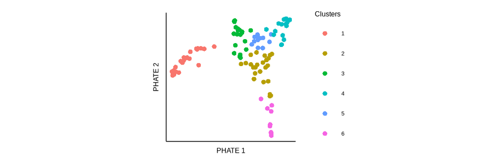

```r
gr.phate(data,"Clusters")
```

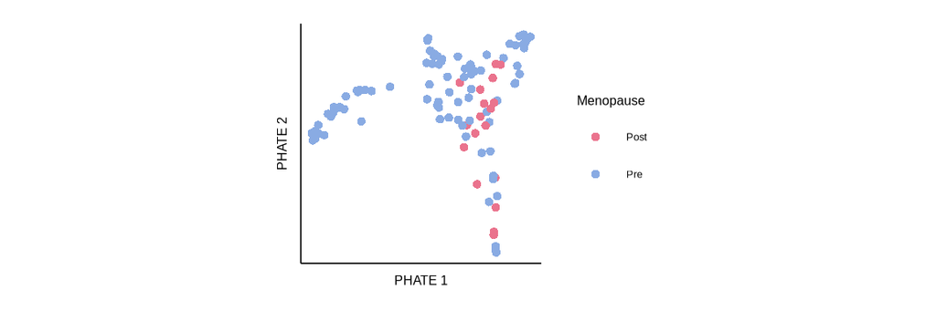

```r
gr.phate(data,"Menopause",color=c("#EA738D", "#89ABE3"))
```

Here we select cluster 1 as the starting point, which is entirely composed of pre-menopausal samples. Subsequently, trajectory inference is performed using the Palantir standard pipline.

```r
root="1"
data=pseudotime(data,root)
```

The CM12 activity decreases as the trajectory progresses.

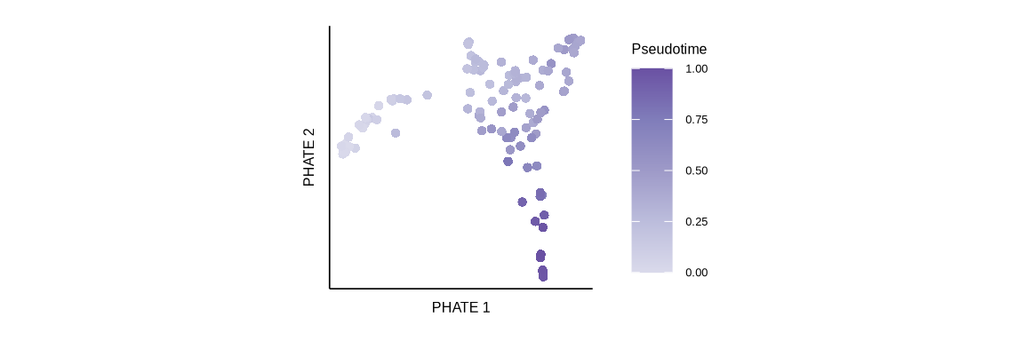

```r
gr.phate(data,"Pseudotime",color=RColorBrewer::brewer.pal(n = 9, name = "Purples")[3:7])
```

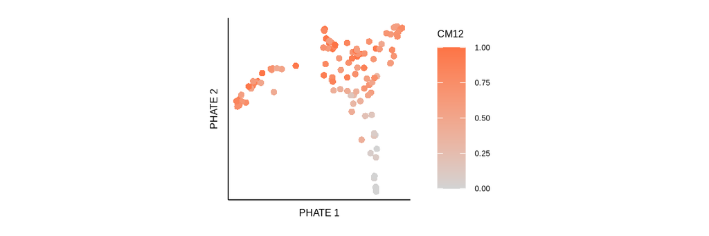

```r
gr.phate(data,c("CM12"),color=c("lightgrey","#FD7446FF"))
```

### Visualizing the menopausal trajectory

The heatmap illustrates the multifaceted changes in breast samples as the trajectory progresses including CM12 activity, menopause status, and sequential changes in cell frequencies.

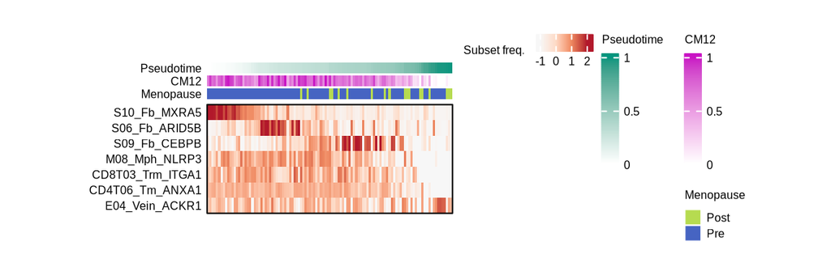

```r
gr.trajectory(data,c("S10_Fb_MXRA5","S06_Fb_ARID5B","S09_Fb_CEBPB","M08_Mph_NLRP3","CD8T03_Trm_ITGA1","CD4T06_Tm_ANXA1","E04_Vein_ACKR1"),c("Pseudotime","CM12","Menopause"))
```